# Week3: Logistic regression"

In this week’s excersize we’ll analyze data on student’s alcohol consumption. It is combined from two questionnaires originally downloaded from: https://archive.ics.uci.edu/ml/datasets/Student+Performance#

Data contains 382 observations (students) of a total of 35 variables, which are listed below:

```
##  [1] "school"     "sex"        "age"        "address"    "famsize"
##  [6] "Pstatus"    "Medu"       "Fedu"       "Mjob"       "Fjob"
## [11] "reason"     "nursery"    "internet"   "guardian"   "traveltime"
## [16] "studytime"  "failures"   "schoolsup"  "famsup"     "paid"
## [21] "activities" "higher"     "romantic"   "famrel"     "freetime"
## [26] "goout"      "Dalc"       "Walc"       "health"     "absences"
## [31] "G1"         "G2"         "G3"         "alc_use"    "high_use"
```

The variables are:

1 school - student’s school (binary: “GP” - Gabriel Pereira or “MS” - Mousinho da Silveira)  
2 sex - student’s sex (binary: “F” - female or “M” - male)  
3 age - student’s age (numeric: from 15 to 22)  
4 address - student’s home address type (binary: “U” - urban or “R” - rural)  
5 famsize - family size (binary: “LE3” - less or equal to 3 or “GT3” - greater than 3)  
6 Pstatus - parent’s cohabitation status (binary: “T” - living together or “A” - apart)  
7 Medu - mother’s education (numeric: 0 - none, 1 - primary education (4th grade), 2 - 5th to 9th grade, 3 - secondary education or 4 - higher education)  
8 Fedu - father’s education (numeric: 0 - none, 1 - primary education (4th grade), 2 - 5th to 9th grade, 3 - secondary education or 4 - higher education)  
9 Mjob - mother’s job (nominal: “teacher”, “health” care related, civil “services” (e.g. administrative or police), “at_home” or “other”)  
10 Fjob - father’s job (nominal: “teacher”, “health” care related, civil “services” (e.g. administrative or police), “at_home” or “other”)  
11 reason - reason to choose this school (nominal: close to “home”, school “reputation”, “course” preference or “other”)  
12 guardian - student’s guardian (nominal: “mother”, “father” or “other”)  
13 traveltime - home to school travel time (numeric: 1 - <15 min., 2 - 15 to 30 min., 3 - 30 min. to 1 hour, or 4 - >1 hour)  
14 studytime - weekly study time (numeric: 1 - <2 hours, 2 - 2 to 5 hours, 3 - 5 to 10 hours, or 4 - >10 hours)  
15 failures - number of past class failures (numeric: n if 1<=n<3, else 4)  
16 schoolsup - extra educational support (binary: yes or no)  
17 famsup - family educational support (binary: yes or no)  
18 paid - extra paid classes within the course subject (Math or Portuguese) (binary: yes or no)  
19 activities - extra-curricular activities (binary: yes or no)  
20 nursery - attended nursery school (binary: yes or no)  
21 higher - wants to take higher education (binary: yes or no)  
22 internet - Internet access at home (binary: yes or no)  
23 romantic - with a romantic relationship (binary: yes or no)  
24 famrel - quality of family relationships (numeric: from 1 - very bad to 5 - excellent)  
25 freetime - free time after school (numeric: from 1 - very low to 5 - very high)  
26 goout - going out with friends (numeric: from 1 - very low to 5 - very high)  
27 Dalc - workday alcohol consumption (numeric: from 1 - very low to 5 - very high)  
28 Walc - weekend alcohol consumption (numeric: from 1 - very low to 5 - very high)  
29 health - current health status (numeric: from 1 - very bad to 5 - very good)  
30 absences - number of school absences (numeric: from 0 to 93)

these grades are related with the course subject, Math or Portuguese:  
31 G1 - first period grade (numeric: from 0 to 20)  
32 G2 - second period grade (numeric: from 0 to 20)  
33 G3 - final grade (numeric: from 0 to 20, output target)  
34 alc_use - average alcohol use on weekdays and weekends (variable created from averagin Dalc and Walc)  
35 high_use - TRUE or FALSE if the use of alchol is >2 (variable created in create_alc.R)  
******************************************************************

## Explore associations with high use of alcohol

With this data, I will analyze how going out with friends (goout), mother’s education (Medu), father’s education (Fedu) and first grade (G1) associate with the use of alcohol (low or high). I hypothesize that:  
-those that go more out with friends think more alcohol  
-low mother and father education associate with higher alcohol use  
-low first grades associate with high alcohol use

Going out:

As hypothesized, 60% of those that are going out with frends the most (5 on 1-5 scale) are high users of alcohol (>2 on 1-5 scale). Of those that go out the least (1), only 13,6% are high alcohol users.

```r
library(dplyr)
```

```r
library(ggplot2)
mytable <- table(high_use = alc$high_use, going_out = alc$goout)
mytable
```

```
##         going_out
## high_use   1   2   3   4   5
##    FALSE  19  84 103  41  21
##    TRUE    3  16  23  40  32
```

```r
prop.table(mytable, 2)
```

```
##         going_out
## high_use         1         2         3         4         5
##    FALSE 0.8636364 0.8400000 0.8174603 0.5061728 0.3962264
##    TRUE  0.1363636 0.1600000 0.1825397 0.4938272 0.6037736
```

Mother’s and father’s education:

```r
mytable <- table(high_use = alc$high_use, mothers_education = alc$Medu)
mytable
```

```
##         mothers_education
## high_use  0  1  2  3  4
##    FALSE  1 33 80 59 95
##    TRUE   2 18 18 36 40
```

```r
prop.table(mytable, 2)
```

```
##         mothers_education
## high_use         0         1         2         3         4
##    FALSE 0.3333333 0.6470588 0.8163265 0.6210526 0.7037037
##    TRUE  0.6666667 0.3529412 0.1836735 0.3789474 0.2962963
```

Father’s education does not seem to associate with student’s alcohol use as seen from the table below. There were only two students whose father had the lowest education. It seems that in this dataset, parental education do not affect student’s alcohol usage.

```r
mytable <- table(high_use = alc$high_use, fathers_education = alc$Fedu)
mytable
```

```
##         fathers_education
## high_use  0  1  2  3  4
##    FALSE  2 53 75 72 66
##    TRUE   0 24 30 27 33
```

```r
prop.table(mytable, 2)
```

```
##         fathers_education
## high_use         0         1         2         3         4
##    FALSE 1.0000000 0.6883117 0.7142857 0.7272727 0.6666667
##    TRUE  0.0000000 0.3116883 0.2857143 0.2727273 0.3333333
```

First grades:

As seen from the box-plot, lower grades seem to associate with higher alcohol useage. (G1-variable). This notion goes in the hypothetised direction.

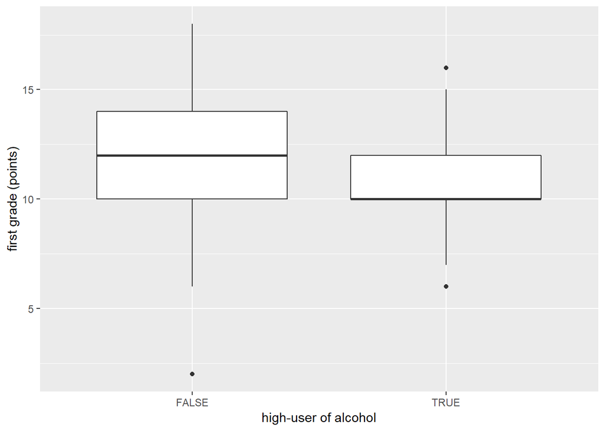

```r
# initialize a plot of high_use and G3
g1 <- ggplot(alc, aes(x = high_use, y = G1))

# define the plot as a boxplot and draw it
g1 + geom_boxplot() + ylab("first grade (points)") + xlab("high-user of alcohol")
```

## Statistical testing of associations with high use of alcohol

The association with variables and high alcohol is next tested with logistic regression. In the first model, going out with friends (scale 1-5 ) and was tested as a explanatory variable. As hypothetized, going out with friends is associated with high alcohol consumption (p = 5.210^-11) with OR (97.5%CI) of 2.14(1.71,2.70).

```r
#logistic regression model
model <- glm(high_use ~ goout, data = alc, family = "binomial")

# print out a summary of the model
summary(model)
```

```
##
## Call:
## glm(formula = high_use ~ goout, family = "binomial", data = alc)
##
## Deviance Residuals:
##     Min       1Q   Median       3Q      Max
## -1.3721  -0.7672  -0.5450   0.9945   2.3082
##
## Coefficients:
##             Estimate Std. Error z value Pr(>|z|)
## (Intercept)  -3.3512     0.4151  -8.073 6.84e-16 ***
## goout         0.7596     0.1157   6.564 5.23e-11 ***
## ---
## Signif. codes:  0 '***' 0.001 '**' 0.01 '*' 0.05 '.' 0.1 ' ' 1
##
## (Dispersion parameter for binomial family taken to be 1)
##
##     Null deviance: 465.68  on 381  degrees of freedom
## Residual deviance: 415.68  on 380  degrees of freedom
## AIC: 419.68
##
## Number of Fisher Scoring iterations: 4
```

```r
# print out the coefficients of the model
coef <-coef(model)
# compute odds ratios (OR)
OR <- coef %>% exp

# compute confidence intervals (CI)
CI <- confint(model) %>% exp
# print out the odds ratios with their confidence intervals
cbind(OR, CI)
```

```
##                     OR      2.5 %     97.5 %
## (Intercept) 0.03504298 0.01505792 0.07687797
## goout       2.13743726 1.71351154 2.69965289
```

Parental education did not associate statistically significantly (P>0.05) with high use of alcohol,and odds ratios were close to one: mothernal education: OR (97.5%CI); 0.98 (0.75, 1.29) and father education: 1.06 (0.81, 1.38). This data therefore does not support my hypothesis that lower parental education would associate with higher alcohol intake of children (student).

```r
# Both variables are shown as integers (1-5) in the data. I think, these variables could have also been presented as factors, because education has true levels. No changes were made however, parental education was stuedied with numeric (integers 1-5 ) values.
```

```r
#logistic regression model
model <- glm(high_use ~ Medu + Fedu, data = alc, family = "binomial")

# print out a summary of the model
summary(model)
```

```
##
## Call:
## glm(formula = high_use ~ Medu + Fedu, family = "binomial", data = alc)
##
## Deviance Residuals:
##     Min       1Q   Median       3Q      Max
## -0.8758  -0.8495  -0.8292   1.5266   1.6043
##
## Coefficients:
##             Estimate Std. Error z value Pr(>|z|)
## (Intercept) -0.95912    0.32702  -2.933  0.00336 **
## Medu        -0.01553    0.13599  -0.114  0.90910
## Fedu         0.05743    0.13478   0.426  0.67005
## ---
## Signif. codes:  0 '***' 0.001 '**' 0.01 '*' 0.05 '.' 0.1 ' ' 1
##
## (Dispersion parameter for binomial family taken to be 1)
##
##     Null deviance: 465.68  on 381  degrees of freedom
## Residual deviance: 465.45  on 379  degrees of freedom
## AIC: 471.45
##
## Number of Fisher Scoring iterations: 4
```

```r
# print out the coefficients of the model
coef <-coef(model)

# compute odds ratios (OR)
OR <- coef %>% exp

# compute confidence intervals (CI)
CI <- confint(model) %>% exp
#print out the odds ratios with their confidence intervals
cbind(OR, CI)
```

```
##                    OR     2.5 %    97.5 %
## (Intercept) 0.3832287 0.1992008 0.7200188
## Medu        0.9845937 0.7538507 1.2865179
## Fedu        1.0591089 0.8139895 1.3824989
```

Last I hypotethized that lower first grades are associated with high alcohol use. This was true (p = 0.004, OR(97.5%CI):0.88(0.81,0.96)).

```r
#logistic regression model
model <- glm(high_use ~ G1, data = alc, family = "binomial")

# print out a summary of the model
summary(model)
```

```
##
## Call:
## glm(formula = high_use ~ G1, family = "binomial", data = alc)
##
## Deviance Residuals:
##     Min       1Q   Median       3Q      Max
## -1.3134  -0.9015  -0.7279   1.4108   1.8198
##
## Coefficients:
##             Estimate Std. Error z value Pr(>|z|)
## (Intercept)  0.56528    0.49487   1.142  0.25334
## G1          -0.12558    0.04328  -2.902  0.00371 **
## ---
## Signif. codes:  0 '***' 0.001 '**' 0.01 '*' 0.05 '.' 0.1 ' ' 1
##
## (Dispersion parameter for binomial family taken to be 1)
##
##     Null deviance: 465.68  on 381  degrees of freedom
## Residual deviance: 456.91  on 380  degrees of freedom
## AIC: 460.91
##
## Number of Fisher Scoring iterations: 4
```

```r
# print out the coefficients of the model
coef <-coef(model)

# compute odds ratios (OR)
OR <- coef %>% exp

# compute confidence intervals (CI)
CI <- confint(model) %>% exp
#print out the odds ratios with their confidence intervals
cbind(OR, CI)
```

```
##                    OR     2.5 %    97.5 %
## (Intercept) 1.7599464 0.6700469 4.6866051
## G1          0.8819812 0.8088857 0.9588772
```